# Доклад

Квантовое шифрование. Квантовая передача информации

Шалыгин Г. Э.

Российский университет дружбы народов, Москва, Россия

# Информация

## Докладчик

- Шалыгин Георгий Эдуардович
- студент НФИ-02-20
- Российский университет дружбы народов

# Вводная часть

## Актуальность

- Информация является одним из самых ценных ресурсов. Ее защита от несанкционированного доступа является одной из важнейших задач информационной безопасности.
- Развитие квантовых вычислений угрожает классическим криптографическим методам, таким как RSA и ECC. Поиск новых методов шифрования становится актуальным.
- Квантовое шифрование обеспечивает более высокий уровень безопасности при передаче данных, попытка перехвата может быть обнаружена.

## Цели и задачи

- Цель: изучить принципы и алгоритмы квантового шифрования.
- Задачи доклада:
  - Рассмотреть основные понятия квантового шифрования и квантовой передачи информации.
  - Познакомиться с основными протоколами квантового шифрования.
  - Обсудить перспективы развития квантового шифрования и квантовой передачи информации.

## Основы квантовой криптографии

- Основана на передаче квантовых состояний и принципах квантовой механики.
- В общем случае, протокол квантового шифрования включает в себя следующие этапы:
  1. **Генерация секретного ключа**. На этом этапе Alice и Bob генерируют секретный ключ, используя один из основных протоколов квантового обмена ключами.
  2. **Шифрование сообщения**. На этом этапе Alice и Bob используют классические метод симметричного шифрования для шифрования сообщения с использованием секретного ключа.
  3. **Передача сообщения**.
  4. **Расшифровка сообщения**.

## Поляризация фотонов

- Поляризация, колебание электрического поля *E⃗*. Пример линейно поляризованных волн показан на рисунке.
- *a*, *b* – базис +, горизонтально-вертикальный (H/V); 45<sup>*o*</sup>, 135<sup>*o*</sup> – базис $×$, и диагонально-антидиагональный (D/A).

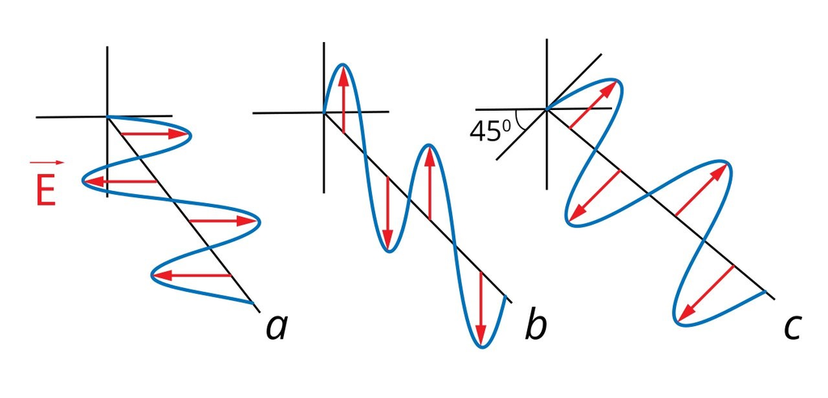

  Поляризованные волны

## Передача бита с помощью фотона

- Рассмотрим два базиса: горизонтально-вертикальный(+) и диагональный ($×$).

  Пусть — и $\diagup$ соответствует 0, | и $\diagdown$ соответствуют 1.
- Два участника: один поляризует фотон и отправляет другому. Другой измеряет поляризацию, случайно выбирая базис.
- Если фотон был поляризован в базисе + и измерен в том же базисе, то получатель однозначно узнает закодированный бит.
- Если же для измерения был выбран базис $×$, то есть один из фильтров: 45<sup>*o*</sup> или 135<sup>*o*</sup>, свет проходит через эти фильтры с вероятностью $\frac{1}{2}$, то есть закодированный бит узнать не получится. Этот принцип отражен на рисунке.

## Иллюстрация измерения поляризации

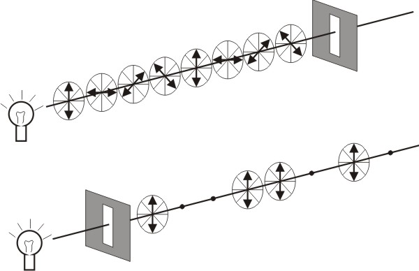

Измерение поляризации

## Протокол BB84 (1984 г., Ч. Беннетт, Ж. Брассар)

Шаги алгоритма следующие:

1. Алиса шифрует передаваемую строку битов с помощью фотонов, поляризованных согласно договорённости. Для каждого бита она случайно выбирает базис: + или $×$.

## Протокол BB84 (Ч. Беннетт, Ж. Брассар, 1984 г.)

2. Боб принимает полученные импульсы и декодирует. Для каждого импульса (считаем, фотона) он выбирает случайно базис (+ или $×$) и измеряет состояние фотона в данном базисе.
3. После оба участника обмениваются последовательностью выбора базисов для поляризации и измерения поляризации фотонов. Из вышесказанного следует, что биты, закодированные и прочитанные в одних базисах, будут известны обоим участникам. Эти биты и принимаются как общий секретный ключ.

- Может использовать неортогональные квантовые состояния.
- Показывает принципиальную возможность такого подхода.
- Использует меньше состояний.

## Протокол E91 (А. Эркерт, 1991 г.)

- Основан на квантовой запутанности.
- Создаются ЭПР-пары фотонов, фотоны из которых отправляются Алисе и Бобу.
- Если базис совпал, то бит сохраняется.

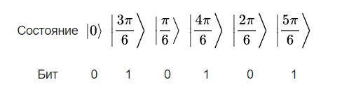

Отдельные состояния

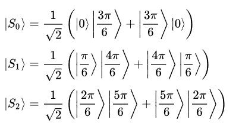

Запутанные состояния

## Детекция ошибок

- Способ был предложен 1991 году Ч. Беннетом.
- Последовательности Алисы и Боба перемешиваются и разбиваются на блоки.
- Основная идея состоит в проверке чётности блоков: блоки проверяют на чётность в несколько итераций, уменьшая каждый размер именно тех блоков, чётность которых не совпала. Достаточно мелкие блоки отбрасываются при обнаружении в них ошибки.
- Неравенства Белла для алгоритмов на ЭПР-парах.

## Реализация

- 1989 г., Беннет и Брассар, Исследовательский центр IBM. Квантовый канал длиной 32 см.
- 48 км, Национальная лаборатория в Лос-Аламосе.
- 67 км, GAP Optique.
- 87 км, Mitsubishi Electric. Скорость – 1 байт/с.
- Команда исследователей из Китая, Сингапура, Великобритании смогла с помощью спутника «Мо-Цзы» объединить города Наньшань и Дэлинха: 1120 км.

# Вывод

- Передовая, развивающаяся область, защищено от атаки с помощью квантовых вычислений.
- Другой уровень защищенности по сравнению с классическими подходами.
- Сложные в реализации технологии.
- ResearchAndMarkets: рынок квантовой криптографии оценен в $93,1 млн.